# Tugas Praktikum 1 MPDW

Robertus Mozart Sinaga - G1401231032

2025-08-31

```r
library(readxl)
library(readr)
library(rio)
library(forecast)
```

```r
library(graphics)
library(tseries)
library(TTR)
library(TSA)
library(ggplot2)
```

###DATA

```r
weather <- read.csv("C:/Users/Robert/Downloads/cleaned_weather.csv")
```

#### Mengambil 100 Data

```r
data <- weather[401:500, c("date","VPdef")]
data
```

```
##               date VPdef
## 401 1/3/2020 18:50  1.89
## 402 1/3/2020 19:00  1.98
## 403 1/3/2020 19:10  2.04
## 404 1/3/2020 19:20  2.03
## 405 1/3/2020 19:30  1.97
## 406 1/3/2020 19:40  2.05
## 407 1/3/2020 19:50  2.06
## 408 1/3/2020 20:00  2.11
## 409 1/3/2020 20:10  2.19
## 410 1/3/2020 20:20  2.19
## 411 1/3/2020 20:30  2.17
## 412 1/3/2020 20:40  2.18
## 413 1/3/2020 20:50  2.17
## 414 1/3/2020 21:00  2.25
```

[output cut: 86 more lines]

```r
data$VPdef <- as.numeric(data$VPdef)
data$VPdef
```

```
##   [1] 1.89 1.98 2.04 2.03 1.97 2.05 2.06 2.11 2.19 2.19 2.17 2.18 2.17 2.25 2.22
##  [16] 2.21 2.17 2.11 2.08 2.14 2.07 1.73 1.54 1.53 1.59 1.70 1.77 1.71 1.37 1.12
##  [31] 1.09 1.22 1.43 1.37 1.29 1.32 1.38 1.41 1.48 1.42 1.30 1.26 1.33 1.41 1.43
##  [46] 1.44 1.61 1.57 1.35 1.25 1.25 1.20 1.21 1.27 1.38 1.46 1.50 1.54 1.58 1.57
##  [61] 1.57 1.58 1.61 1.64 1.66 1.67 1.67 1.67 1.64 1.56 1.52 1.51 1.54 1.52 1.58
##  [76] 1.61 1.60 1.60 1.63 1.67 1.71 1.77 1.80 1.84 1.84 1.82 1.85 1.91 1.96 1.97
##  [91] 2.03 2.07 2.13 2.19 2.20 2.22 2.13 2.08 2.06 2.02
```

#### Data Time Series

```r
data_ts <- ts(data$VPdef)
data_ts
```

```
## Time Series:
## Start = 1
## End = 100
## Frequency = 1
##   [1] 1.89 1.98 2.04 2.03 1.97 2.05 2.06 2.11 2.19 2.19 2.17 2.18 2.17 2.25 2.22
##  [16] 2.21 2.17 2.11 2.08 2.14 2.07 1.73 1.54 1.53 1.59 1.70 1.77 1.71 1.37 1.12
##  [31] 1.09 1.22 1.43 1.37 1.29 1.32 1.38 1.41 1.48 1.42 1.30 1.26 1.33 1.41 1.43
##  [46] 1.44 1.61 1.57 1.35 1.25 1.25 1.20 1.21 1.27 1.38 1.46 1.50 1.54 1.58 1.57
##  [61] 1.57 1.58 1.61 1.64 1.66 1.67 1.67 1.67 1.64 1.56 1.52 1.51 1.54 1.52 1.58
##  [76] 1.61 1.60 1.60 1.63 1.67 1.71 1.77 1.80 1.84 1.84 1.82 1.85 1.91 1.96 1.97
##  [91] 2.03 2.07 2.13 2.19 2.20 2.22 2.13 2.08 2.06 2.02
```

### EKSPLORASI DATA

#### Ringkasan Data

```r
summary(data_ts)
```

```
##    Min. 1st Qu.  Median    Mean 3rd Qu.    Max.
##   1.090   1.475   1.650   1.713   2.033   2.250
```

#### Plot Data Time Series

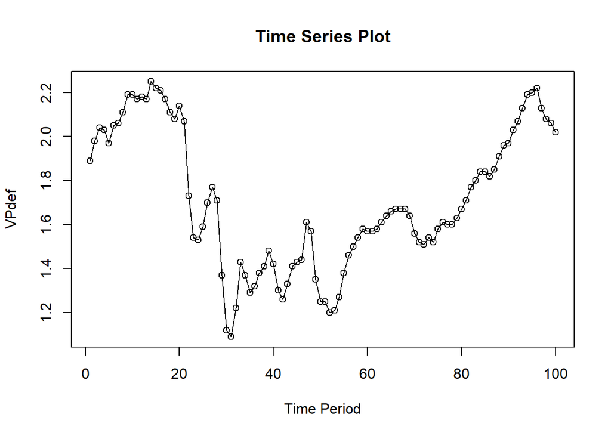

```r
ts.plot(data_ts, xlab="Time Period", ylab="VPdef",
        main = "Time Series Plot")
points(data_ts)
```

##### Data tidak memiliki kecenderungan tren naik / turun secara konsisten, maka bisa dikatakan tidak memiliki tren karena hanya berupa fluktuasi lokal.

### SINGLE MOVING AVERAGE (SMA)

#### Split Data (80% Data Train, 20% Data Test)

```r
# jumlah data
n <- nrow(data)
n
```

```
## [1] 100
```

```r
# batas data train 80%
n_train <- floor(0.8 * n)
n_train
```

```
## [1] 80
```

```r
# bagi data
training <- data[1:n_train, ]
training
```

```
##               date VPdef
## 401 1/3/2020 18:50  1.89
## 402 1/3/2020 19:00  1.98
## 403 1/3/2020 19:10  2.04
## 404 1/3/2020 19:20  2.03
## 405 1/3/2020 19:30  1.97
## 406 1/3/2020 19:40  2.05
## 407 1/3/2020 19:50  2.06
## 408 1/3/2020 20:00  2.11
## 409 1/3/2020 20:10  2.19
## 410 1/3/2020 20:20  2.19
## 411 1/3/2020 20:30  2.17
## 412 1/3/2020 20:40  2.18
## 413 1/3/2020 20:50  2.17
## 414 1/3/2020 21:00  2.25
```

[output cut: 66 more lines]

```r
testing  <- data[(n_train+1):n, ]
testing
```

```
##               date VPdef
## 481  1/4/2020 8:10  1.71
## 482  1/4/2020 8:20  1.77
## 483  1/4/2020 8:30  1.80
## 484  1/4/2020 8:40  1.84
## 485  1/4/2020 8:50  1.84
## 486  1/4/2020 9:00  1.82
## 487  1/4/2020 9:10  1.85
## 488  1/4/2020 9:20  1.91
## 489  1/4/2020 9:30  1.96
## 490  1/4/2020 9:40  1.97
## 491  1/4/2020 9:50  2.03
## 492 1/4/2020 10:00  2.07
## 493 1/4/2020 10:10  2.13
## 494 1/4/2020 10:20  2.19
## 495 1/4/2020 10:30  2.20
## 496 1/4/2020 10:40  2.22
## 497 1/4/2020 10:50  2.13
## 498 1/4/2020 11:00  2.08
## 499 1/4/2020 11:10  2.06
## 500 1/4/2020 11:20  2.02
```

```r
# ubah ke time series
training_ts <- ts(training$VPdef)
training_ts
```

```
## Time Series:
## Start = 1
## End = 80
## Frequency = 1
##  [1] 1.89 1.98 2.04 2.03 1.97 2.05 2.06 2.11 2.19 2.19 2.17 2.18 2.17 2.25 2.22
## [16] 2.21 2.17 2.11 2.08 2.14 2.07 1.73 1.54 1.53 1.59 1.70 1.77 1.71 1.37 1.12
## [31] 1.09 1.22 1.43 1.37 1.29 1.32 1.38 1.41 1.48 1.42 1.30 1.26 1.33 1.41 1.43
## [46] 1.44 1.61 1.57 1.35 1.25 1.25 1.20 1.21 1.27 1.38 1.46 1.50 1.54 1.58 1.57
## [61] 1.57 1.58 1.61 1.64 1.66 1.67 1.67 1.67 1.64 1.56 1.52 1.51 1.54 1.52 1.58
## [76] 1.61 1.60 1.60 1.63 1.67
```

```r
testing_ts <- ts(testing$VPdef)
testing_ts
```

```
## Time Series:
## Start = 1
## End = 20
## Frequency = 1
##  [1] 1.71 1.77 1.80 1.84 1.84 1.82 1.85 1.91 1.96 1.97 2.03 2.07 2.13 2.19 2.20
## [16] 2.22 2.13 2.08 2.06 2.02
```

#### Plot Data Train

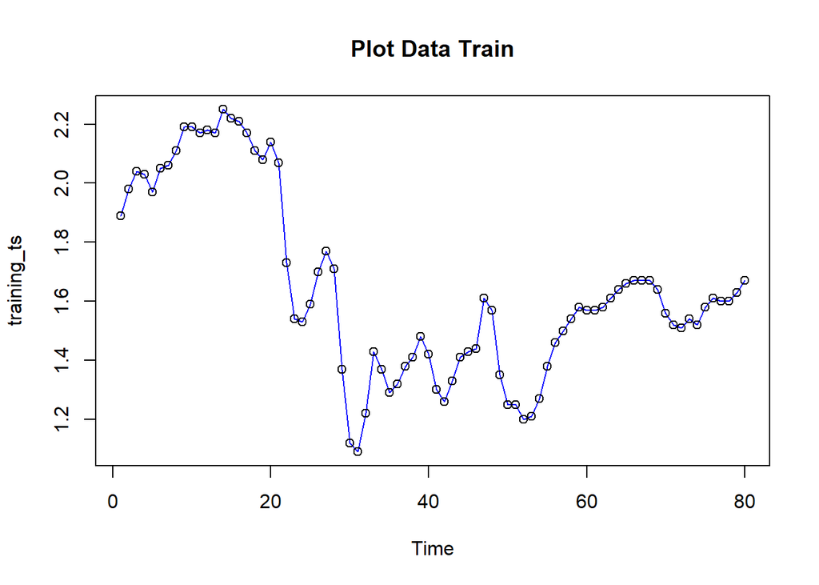

```r
plot(training_ts, col="blue",main="Plot Data Train")
points(training_ts)
```

#### Plot Data Test

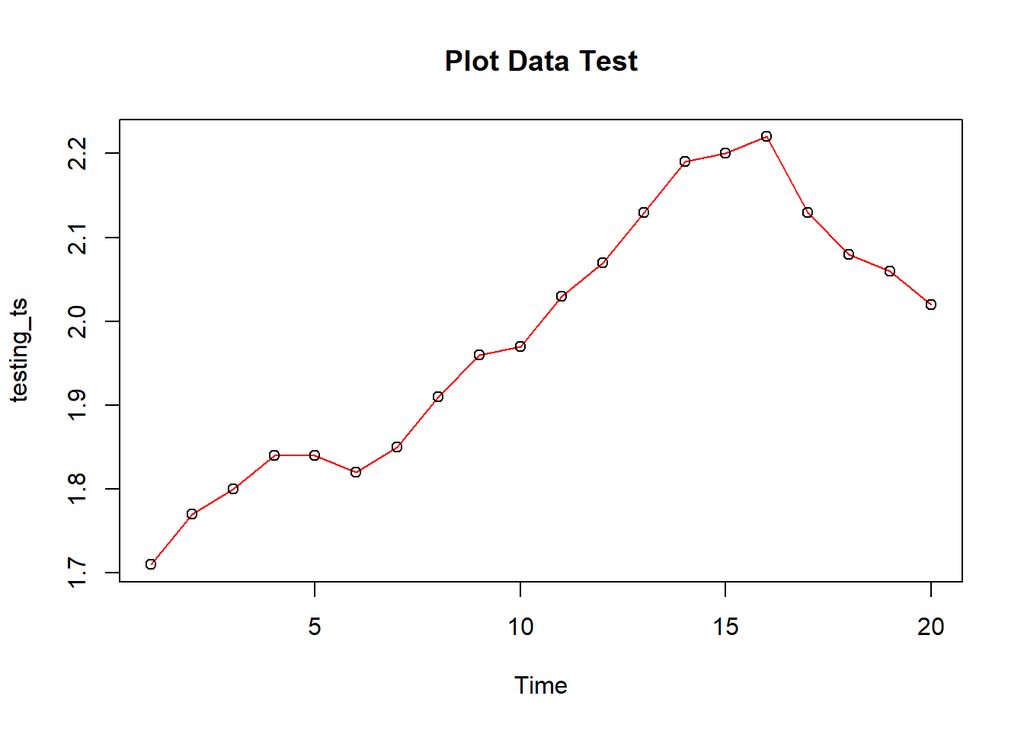

```r
plot(testing_ts, col="red",main="Plot Data Test")
points(testing_ts)
```

#### Plot Semua Data

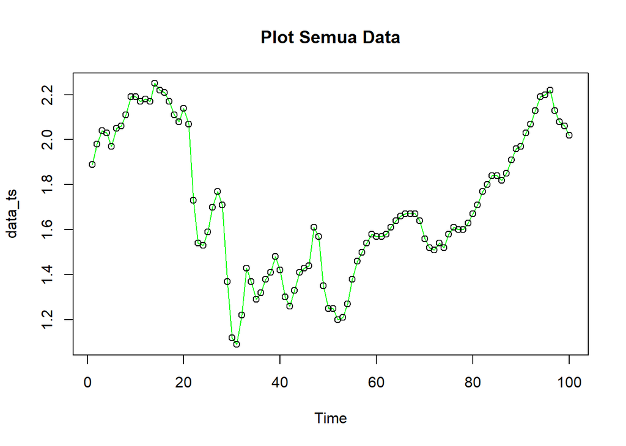

```r
plot(data_ts, col="green",main="Plot Semua Data")
points(data_ts)
```

```r
data_sma <- SMA(training_ts, n=4)
data_sma
```

```
## Time Series:
## Start = 1
## End = 80
## Frequency = 1
##  [1]     NA     NA     NA 1.9850 2.0050 2.0225 2.0275 2.0475 2.1025 2.1375
## [11] 2.1650 2.1825 2.1775 2.1925 2.2050 2.2125 2.2125 2.1775 2.1425 2.1250
## [21] 2.1000 2.0050 1.8700 1.7175 1.5975 1.5900 1.6475 1.6925 1.6375 1.4925
## [31] 1.3225 1.2000 1.2150 1.2775 1.3275 1.3525 1.3400 1.3500 1.3975 1.4225
## [41] 1.4025 1.3650 1.3275 1.3250 1.3575 1.4025 1.4725 1.5125 1.4925 1.4450
## [51] 1.3550 1.2625 1.2275 1.2325 1.2650 1.3300 1.4025 1.4700 1.5200 1.5475
## [61] 1.5650 1.5750 1.5825 1.6000 1.6225 1.6450 1.6600 1.6675 1.6625 1.6350
## [71] 1.5975 1.5575 1.5325 1.5225 1.5375 1.5625 1.5775 1.5975 1.6100 1.6250
```

##### Data pemulusan pada periode ke-t digunakan sebagai nilai peramalan pada periode ke t+1, hasil peramalannya ditunjukkan di bawah ini.

```r
data_ramal <- c(NA,data_sma)
data_ramal
```

```
##  [1]     NA     NA     NA     NA 1.9850 2.0050 2.0225 2.0275 2.0475 2.1025
## [11] 2.1375 2.1650 2.1825 2.1775 2.1925 2.2050 2.2125 2.2125 2.1775 2.1425
## [21] 2.1250 2.1000 2.0050 1.8700 1.7175 1.5975 1.5900 1.6475 1.6925 1.6375
## [31] 1.4925 1.3225 1.2000 1.2150 1.2775 1.3275 1.3525 1.3400 1.3500 1.3975
## [41] 1.4225 1.4025 1.3650 1.3275 1.3250 1.3575 1.4025 1.4725 1.5125 1.4925
## [51] 1.4450 1.3550 1.2625 1.2275 1.2325 1.2650 1.3300 1.4025 1.4700 1.5200
## [61] 1.5475 1.5650 1.5750 1.5825 1.6000 1.6225 1.6450 1.6600 1.6675 1.6625
## [71] 1.6350 1.5975 1.5575 1.5325 1.5225 1.5375 1.5625 1.5775 1.5975 1.6100
## [81] 1.6250
```

```r
data_gab <- cbind(
  aktual=c(data_ts),
  pemulusan=c(data_sma,rep(NA,24)),
  ramalan=c(data_ramal,rep(data_ramal[length(data_ramal)],23)))
data_gab
```

```
##        aktual pemulusan ramalan
##   [1,]   1.89        NA      NA
##   [2,]   1.98        NA      NA
##   [3,]   2.04        NA      NA
##   [4,]   2.03    1.9850      NA
##   [5,]   1.97    2.0050  1.9850
##   [6,]   2.05    2.0225  2.0050
##   [7,]   2.06    2.0275  2.0225
##   [8,]   2.11    2.0475  2.0275
##   [9,]   2.19    2.1025  2.0475
##  [10,]   2.19    2.1375  2.1025
##  [11,]   2.17    2.1650  2.1375
##  [12,]   2.18    2.1825  2.1650
##  [13,]   2.17    2.1775  2.1825
##  [14,]   2.25    2.1925  2.1775
```

[output cut: 90 more lines]

#### Plot Hasil Pemulusan dan Peramalan

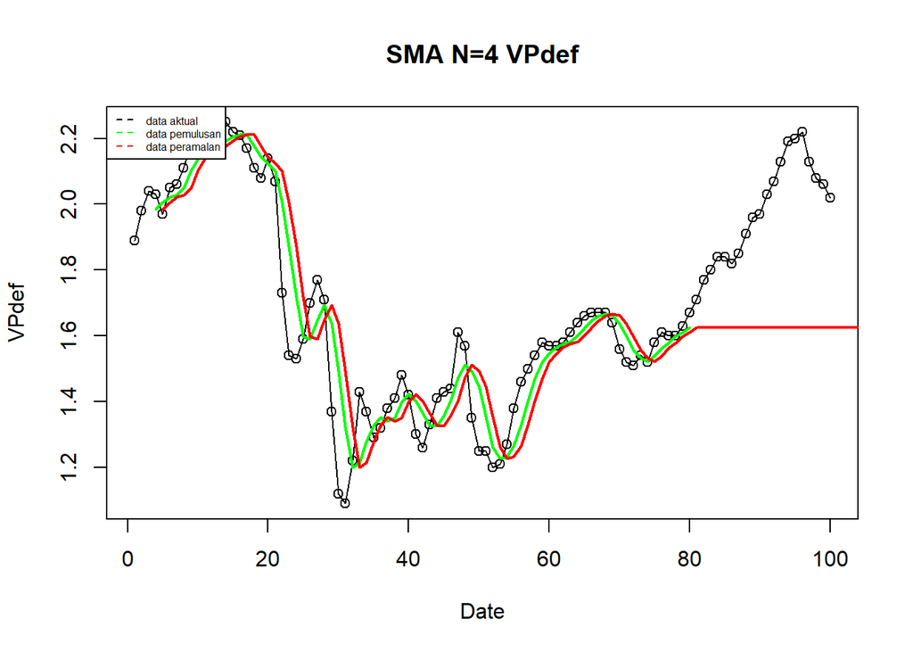

```r
ts.plot(data_ts, xlab="Date", ylab="VPdef", main= "SMA N=4 VPdef")
points(data_ts)
lines(data_gab[,2],col="green",lwd=2)
lines(data_gab[,3],col="red",lwd=2)
legend("topleft",c("data aktual","data pemulusan","data peramalan"), lty=8, col=c("black","green","red"), cex=0.5)
```

```r
#Hitung keakuratan data train
error_train_sma = training_ts-data_ramal[1:length(training_ts)]

SSE_train_sma = sum(error_train_sma[5:length(training_ts)]^2)
MSE_train_sma = mean(error_train_sma[5:length(training_ts)]^2)
MAPE_train_sma = mean(abs((error_train_sma[5:length(training_ts)]/training_ts[5:length(training_ts)])*100))

akurasi_train_sma <- matrix(c(SSE_train_sma, MSE_train_sma, MAPE_train_sma))
row.names(akurasi_train_sma)<- c("SSE", "MSE", "MAPE")
colnames(akurasi_train_sma) <- c("Akurasi m = 4")
akurasi_train_sma
```

```
##      Akurasi m = 4
## SSE     1.69440000
## MSE     0.02229474
## MAPE    7.17194126
```

```r
# Ambil data aktual (baris 81-104, kolom 1)
actual_test <- data_gab[81:104, 1]

# Ambil data ramalan (baris 81-104, kolom 3)
forecast_test <- data_gab[81:104, 3]

# Hitung error
error_test_sma <- actual_test - forecast_test

# Hitung metrik
SSE_test_sma <- sum(error_test_sma^2)
MSE_test_sma <- mean(error_test_sma^2)
MAPE_test_sma <- mean(abs(error_test_sma / actual_test * 100))

# Simpan dalam matrix
akurasi_test_sma <- matrix(c(SSE_test_sma, MSE_test_sma, MAPE_test_sma))
row.names(akurasi_test_sma) <- c("SSE", "MSE", "MAPE")
colnames(akurasi_test_sma) <- c("Akurasi m = 4")

akurasi_test_sma
```

```
##      Akurasi m = 4
## SSE      3.5132000
## MSE      0.1463833
## MAPE    17.5437829
```

### INTERPRETASI SMA

##### Training : MAPE = 7.17% (cukup baik karena 5% ≤ MAPE < 10%), model mampu mengikuti pola data train. Testing : MAPE = 17.54% (kurang baik), namun model masih bisa & cukup layak digunakan untuk peramalan.

### DOUBLE MOVING AVERAGE (DMA)

```r
dma <- SMA(data_sma, n = 4)
At <- 2*data_sma - dma
Bt <- 2/(4-1)*(data_sma - dma)
data_dma<- At+Bt
data_ramal<- c(NA, data_dma)

t = 1:24
f = c()

for (i in t) {
  f[i] = At[length(At)] + Bt[length(Bt)]*(i)
}

data_gab2 <- cbind(aktual = c(data_ts),
                   pemulusan1 = c(data_sma,rep(NA,24)),
                   pemulusan2 = c(dma, rep(NA,24)),
                   At = c(At, rep(NA,24)),
                   Bt = c(Bt,rep(NA,24)),
                   ramalan = c(data_ramal, f[-1]))
data_gab2
```

```
##        aktual pemulusan1 pemulusan2       At            Bt   ramalan
##   [1,]   1.89         NA         NA       NA            NA        NA
##   [2,]   1.98         NA         NA       NA            NA        NA
##   [3,]   2.04         NA         NA       NA            NA        NA
##   [4,]   2.03     1.9850         NA       NA            NA        NA
##   [5,]   1.97     2.0050         NA       NA            NA        NA
##   [6,]   2.05     2.0225         NA       NA            NA        NA
##   [7,]   2.06     2.0275   2.010000 2.045000  1.166667e-02        NA
##   [8,]   2.11     2.0475   2.025625 2.069375  1.458333e-02 2.0566667
##   [9,]   2.19     2.1025   2.050000 2.155000  3.500000e-02 2.0839583
##  [10,]   2.19     2.1375   2.078750 2.196250  3.916667e-02 2.1900000
##  [11,]   2.17     2.1650   2.113125 2.216875  3.458333e-02 2.2354167
##  [12,]   2.18     2.1825   2.146875 2.218125  2.375000e-02 2.2514583
##  [13,]   2.17     2.1775   2.165625 2.189375  7.916667e-03 2.2418750
##  [14,]   2.25     2.1925   2.179375 2.205625  8.750000e-03 2.1972917
```

[output cut: 90 more lines]

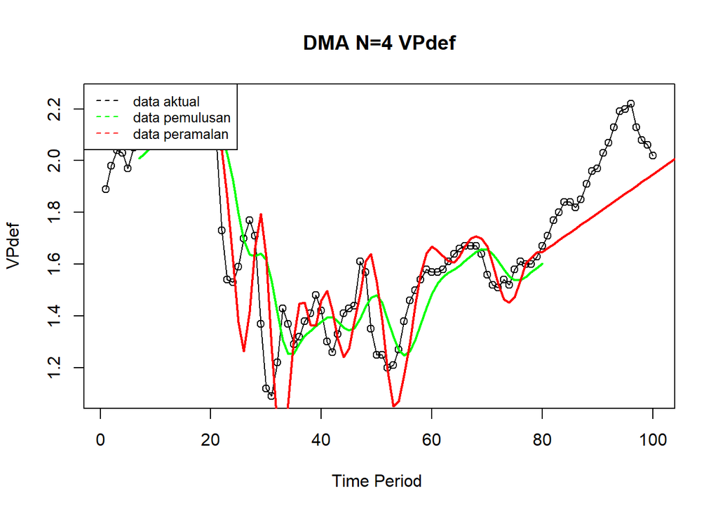

```r
ts.plot(data_ts, xlab="Time Period ", ylab="VPdef", main= "DMA N=4 VPdef")
points(data_ts)
lines(data_gab2[,3],col="green",lwd=2)
lines(data_gab2[,6],col="red",lwd=2)
legend("topleft",c("data aktual","data pemulusan","data peramalan"), lty=8, col=c("black","green","red"), cex=0.8)
```

```r
#Menghitung keakuratan data train
error_train_dma = training_ts-data_ramal[1:length(training_ts)]

SSE_train_dma = sum(error_train_dma[8:length(training_ts)]^2)
MSE_train_dma = mean(error_train_dma[8:length(training_ts)]^2)
MAPE_train_dma = mean(abs((error_train_dma[8:length(training_ts)]/training_ts[8:length(training_ts)])*100))

akurasi_train_dma <- matrix(c(SSE_train_dma, MSE_train_dma, MAPE_train_dma))
row.names(akurasi_train_dma)<- c("SSE", "MSE", "MAPE")
colnames(akurasi_train_dma) <- c("Akurasi m = 4")
akurasi_train_dma
```

```
##      Akurasi m = 4
## SSE     2.17974115
## MSE     0.02985947
## MAPE    8.23115019
```

```r
n_test <- length(testing_ts)
error_test_dma <- testing_ts - data_gab2[(nrow(data_gab2)-n_test+1):nrow(data_gab2), 6]

SSE_test_dma <- sum(error_test_dma^2)
MSE_test_dma <- mean(error_test_dma^2)
MAPE_test_dma <- mean(abs(error_test_dma / testing_ts * 100))

akurasi_test_dma <- matrix(c(SSE_test_dma, MSE_test_dma, MAPE_test_dma))
row.names(akurasi_test_dma) <- c("SSE", "MSE", "MAPE")
colnames(akurasi_test_dma) <- c("Akurasi m = 4")
akurasi_test_dma
```

```
##      Akurasi m = 4
## SSE     0.42042500
## MSE     0.02102125
## MAPE    5.61896547
```

### Simple Exponential Smoothing (SES)

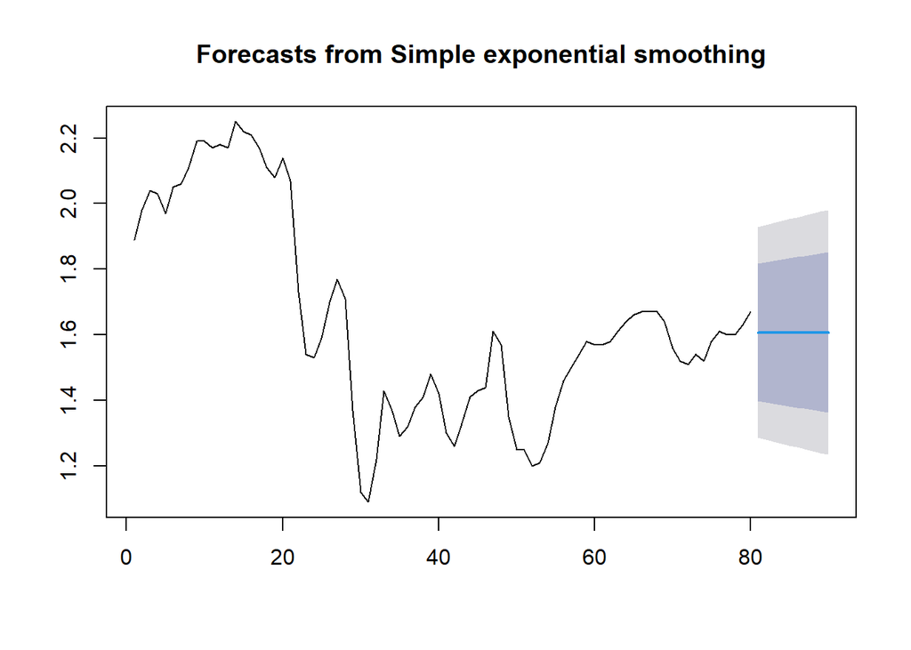

```r
#Ubah ke time series
train_ma_ts <- ts(training$VPdef)
test_ma_ts  <- ts(testing$VPdef)

#Fungsi ses
ses_1 <- ses(train_ma_ts, h = 10, alpha = 0.2)
plot(ses_1)
```

```r
ses_1
```

```
##    Point Forecast    Lo 80    Hi 80    Lo 95    Hi 95
## 81       1.607632 1.398154 1.817109 1.287263 1.928000
## 82       1.607632 1.394006 1.821258 1.280919 1.934345
## 83       1.607632 1.389936 1.825327 1.274695 1.940568
## 84       1.607632 1.385941 1.829322 1.268586 1.946678
## 85       1.607632 1.382017 1.833246 1.262584 1.952679
## 86       1.607632 1.378160 1.837103 1.256686 1.958578
## 87       1.607632 1.374367 1.840896 1.250885 1.964379
## 88       1.607632 1.370635 1.844628 1.245176 1.970087
## 89       1.607632 1.366960 1.848303 1.239557 1.975707
## 90       1.607632 1.363341 1.851922 1.234021 1.981242
```

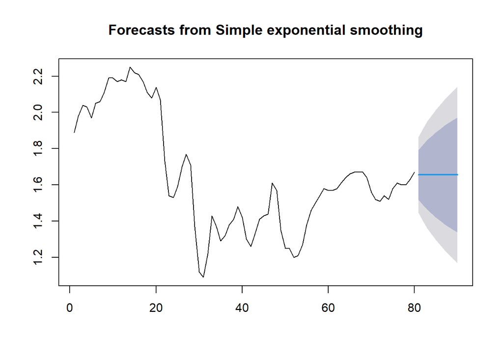

```r
ses_2<- ses(train_ma_ts, h = 10, alpha = 0.7)
plot(ses_2)
```

```r
ses_2
```

```
##    Point Forecast    Lo 80    Hi 80    Lo 95    Hi 95
## 81       1.655267 1.518790 1.791745 1.446543 1.863992
## 82       1.655267 1.488675 1.821859 1.400487 1.910048
## 83       1.655267 1.463226 1.847308 1.361566 1.948969
## 84       1.655267 1.440776 1.869759 1.327231 1.983304
## 85       1.655267 1.420462 1.890072 1.296164 2.014370
## 86       1.655267 1.401771 1.908763 1.267579 2.042956
## 87       1.655267 1.384367 1.926168 1.240961 2.069574
## 88       1.655267 1.368015 1.942519 1.215953 2.094582
## 89       1.655267 1.352545 1.957989 1.192294 2.118241
## 90       1.655267 1.337829 1.972706 1.169787 2.140748
```

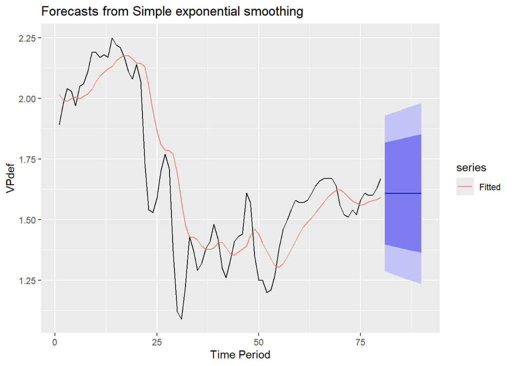

```r
autoplot(ses_1) +
  autolayer(fitted(ses_1), series="Fitted") +
  ylab("VPdef") + xlab("Time Period")
```

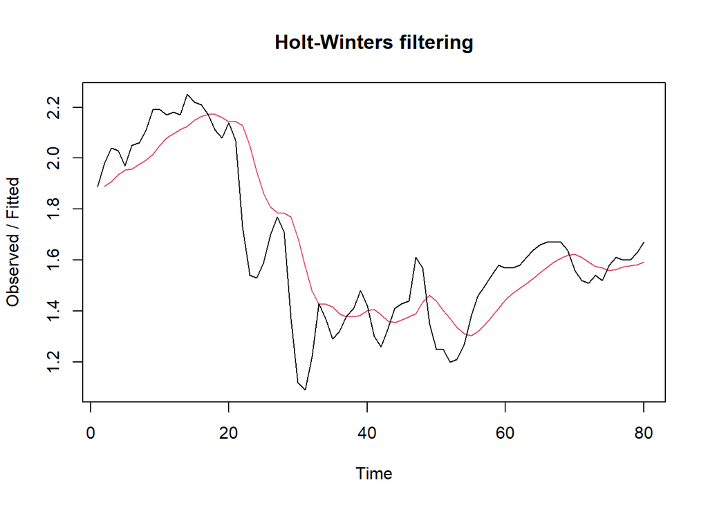

```r
#Fungsi Holtwinter
ses1<- HoltWinters(train_ma_ts, gamma = FALSE, beta = FALSE, alpha = 0.2)
plot(ses1)
```

```r
ramalan1 <- forecast(ses1, h=10)
ramalan1
```

```
##    Point Forecast    Lo 80    Hi 80    Lo 95    Hi 95
## 81       1.607632 1.397188 1.818076 1.285785 1.929478
## 82       1.607632 1.393020 1.822243 1.279411 1.935852
## 83       1.607632 1.388932 1.826332 1.273159 1.942104
## 84       1.607632 1.384919 1.830345 1.267021 1.948242
## 85       1.607632 1.380977 1.834287 1.260993 1.954271
## 86       1.607632 1.377102 1.838162 1.255067 1.960197
## 87       1.607632 1.373291 1.841972 1.249239 1.966025
## 88       1.607632 1.369541 1.845722 1.243504 1.971759
## 89       1.607632 1.365850 1.849413 1.237858 1.977405
## 90       1.607632 1.362214 1.853049 1.232298 1.982966
```

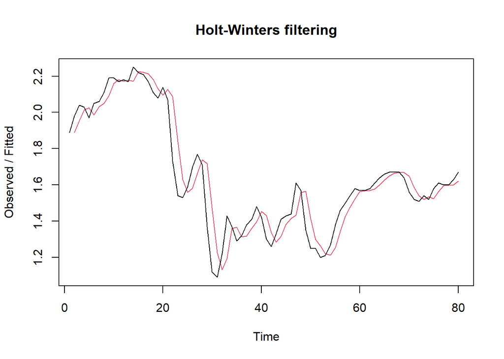

```r
ses2 <- HoltWinters(train_ma_ts, gamma = FALSE, beta = FALSE, alpha = 0.7)
plot(ses2)
```

```r
ramalan2 <- forecast(ses2, h=10)
ramalan2
```

```
##    Point Forecast    Lo 80    Hi 80    Lo 95    Hi 95
## 81       1.655267 1.518814 1.791721 1.446579 1.863955
## 82       1.655267 1.488704 1.821830 1.400531 1.910004
## 83       1.655267 1.463260 1.847275 1.361617 1.948918
## 84       1.655267 1.440813 1.869721 1.327288 1.983247
## 85       1.655267 1.420503 1.890031 1.296227 2.014308
## 86       1.655267 1.401816 1.908719 1.267646 2.042888
## 87       1.655267 1.384414 1.926120 1.241033 2.069501
## 88       1.655267 1.368065 1.942469 1.216030 2.094505
## 89       1.655267 1.352598 1.957937 1.192375 2.118160
## 90       1.655267 1.337884 1.972651 1.169871 2.140664
```

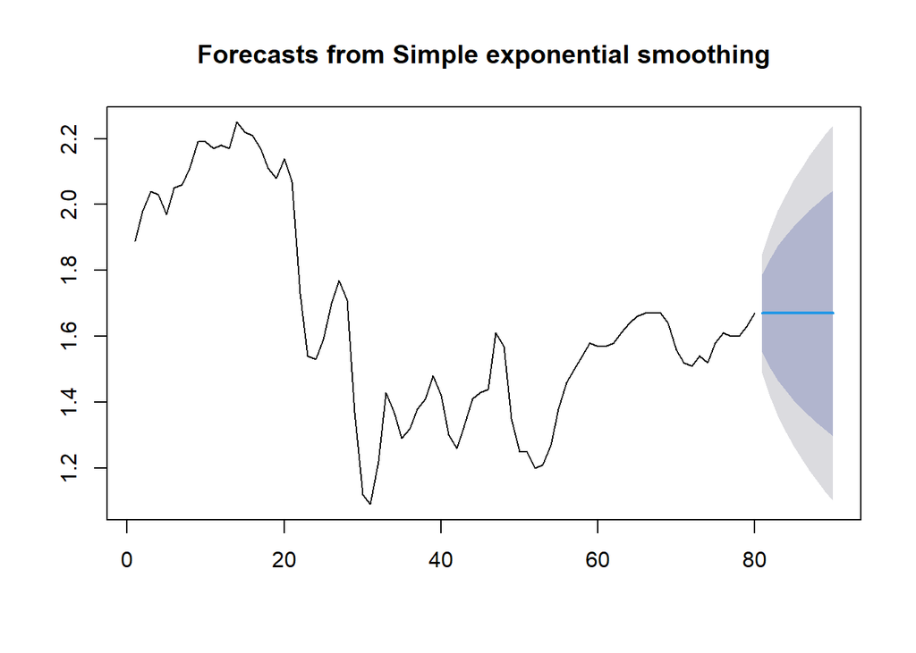

```r
ses_opt <- ses(train_ma_ts, h = 10, alpha = NULL)
plot(ses_opt)
```

```r
ses_opt
```

```
##    Point Forecast    Lo 80    Hi 80    Lo 95    Hi 95
## 81       1.669996 1.552159 1.787833 1.489779 1.850213
## 82       1.669996 1.503357 1.836635 1.415144 1.924848
## 83       1.669996 1.465909 1.874083 1.357872 1.982120
## 84       1.669996 1.434339 1.905653 1.309590 2.030402
## 85       1.669996 1.406525 1.933467 1.267051 2.072941
## 86       1.669996 1.381379 1.958613 1.228594 2.111398
## 87       1.669996 1.358254 1.981738 1.193228 2.146764
## 88       1.669996 1.336731 2.003261 1.160311 2.179681
## 89       1.669996 1.316515 2.023477 1.129394 2.210598
## 90       1.669996 1.297395 2.042597 1.100152 2.239840
```

```r
#Lamda Optimum Holt Winter
HWopt <- HoltWinters(train_ma_ts, gamma = FALSE, beta = FALSE, alpha = NULL)
HWopt
```

```
## Holt-Winters exponential smoothing without trend and without seasonal component.
##
## Call:
## HoltWinters(x = train_ma_ts, alpha = NULL, beta = FALSE, gamma = FALSE)
##
## Smoothing parameters:
##  alpha: 0.9999339
##  beta : FALSE
##  gamma: FALSE
##
## Coefficients:
##       [,1]
## a 1.669997
```

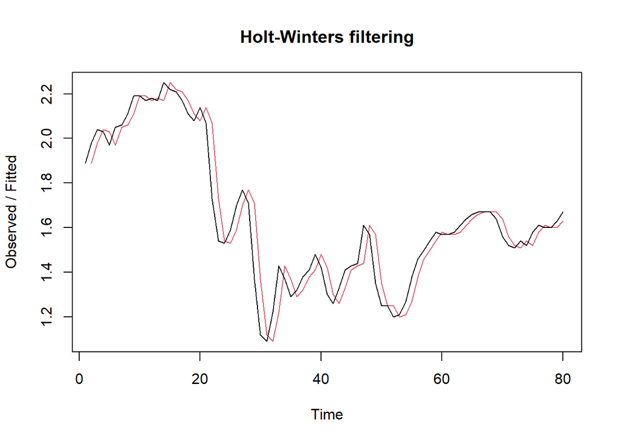

```r
plot(HWopt)
```

```r
ramalanopt<- forecast(HWopt, h=10)
ramalanopt
```

```
##    Point Forecast    Lo 80    Hi 80    Lo 95    Hi 95
## 81       1.669997 1.552217 1.787778 1.489867 1.850128
## 82       1.669997 1.503436 1.836559 1.415263 1.924731
## 83       1.669997 1.466004 1.873991 1.358016 1.981978
## 84       1.669997 1.434447 1.905547 1.309755 2.030240
## 85       1.669997 1.406645 1.933349 1.267235 2.072759
## 86       1.669997 1.381510 1.958484 1.228795 2.111200
## 87       1.669997 1.358396 1.981598 1.193445 2.146550
## 88       1.669997 1.336882 2.003112 1.160542 2.179453
## 89       1.669997 1.316676 2.023319 1.129639 2.210356
## 90       1.669997 1.297564 2.042431 1.100410 2.239585
```

```r
# Keakuratan metode pada data training

# SES dengan alpha = 0.2
SSE1<-ses1$SSE
MSE1<-ses1$SSE/length(train_ma_ts)
RMSE1<-sqrt(MSE1)

akurasi1 <- matrix(c(SSE1,MSE1,RMSE1))
rownames(akurasi1)<- c("SSE", "MSE", "RMSE")
colnames(akurasi1) <- c("Akurasi lamda=0.2")
akurasi1
```

```
##      Akurasi lamda=0.2
## SSE         2.12850468
## MSE         0.02660631
## RMSE        0.16311440
```

```r
# SES dengan alpha = 0.7
SSE2<-ses2$SSE
MSE2<-ses2$SSE/length(train_ma_ts)
RMSE2<-sqrt(MSE2)

akurasi2 <- matrix(c(SSE2,MSE2,RMSE2))
rownames(akurasi2)<- c("SSE", "MSE", "RMSE")
colnames(akurasi2) <- c("Akurasi lamda=0.7")
akurasi2
```

```
##      Akurasi lamda=0.7
## SSE          0.8857118
## MSE          0.0110714
## RMSE         0.1052207
```

```r
# Error masing-masing ramalan
e1   <- as.numeric(ramalan1$mean) - as.numeric(testing$VPdef)
e2   <- as.numeric(ramalan2$mean) - as.numeric(testing$VPdef)
eopt <- as.numeric(ramalanopt$mean) - as.numeric(testing$VPdef)

# SSE / MSE / RMSE
SSEtesting1  <- sum(e1^2)
MSEtesting1  <- mean(e1^2)
RMSEtesting1 <- sqrt(MSEtesting1)

SSEtesting2  <- sum(e2^2)
MSEtesting2  <- mean(e2^2)
RMSEtesting2 <- sqrt(MSEtesting2)

SSEtestingopt  <- sum(eopt^2)
MSEtestingopt  <- mean(eopt^2)
RMSEtestingopt <- sqrt(MSEtestingopt)

# Gabung hasil
hasil_test <- data.frame(
  Model = c("SES α=0.2","SES α=0.7","SES Optimal"),
  SSE = c(SSEtesting1, SSEtesting2, SSEtestingopt),
  MSE = c(MSEtesting1, MSEtesting2, MSEtestingopt),
  RMSE = c(RMSEtesting1, RMSEtesting2, RMSEtestingopt)
)

hasil_test
```

```
##         Model      SSE       MSE      RMSE
## 1   SES α=0.2 3.233364 0.1616682 0.4020798
## 2   SES α=0.7 2.569226 0.1284613 0.3584150
## 3 SES Optimal 2.382233 0.1191116 0.3451255
```

### INTERPRETASI SES

##### Overall SES dengan α kecil kurang cocok untuk data berskala 10 menit yang fluktuatif. SES dengan α tinggi (0.7) atau optimal lebih sesuai karena lebih mampu menangkap pola jangka pendek.

### DES

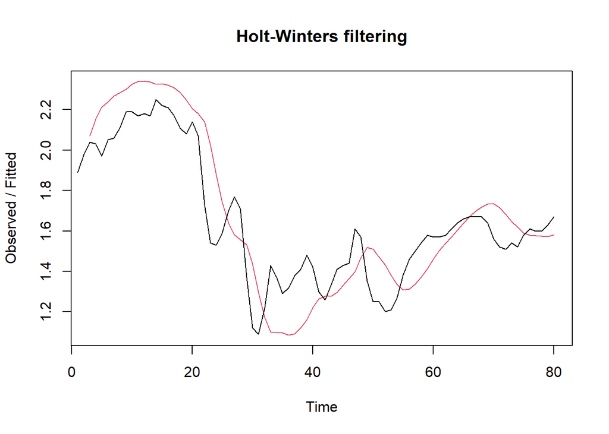

```r
#Lamda=0.2 dan gamma=0.2
des_1<- HoltWinters(train_ma_ts, gamma = FALSE, beta = 0.2, alpha = 0.2)
plot(des_1)
```

```r
#ramalan
ramalandes1<- forecast(des_1, h=10)
ramalandes1
```

```
##    Point Forecast    Lo 80    Hi 80    Lo 95    Hi 95
## 81       1.597967 1.375450 1.820484 1.257657 1.938277
## 82       1.597487 1.368652 1.826323 1.247513 1.947462
## 83       1.597008 1.359842 1.834174 1.234294 1.959722
## 84       1.596528 1.348904 1.844153 1.217819 1.975237
## 85       1.596049 1.335789 1.856308 1.198016 1.994081
## 86       1.595569 1.320511 1.870627 1.174903 2.016234
## 87       1.595089 1.303125 1.887053 1.148569 2.041610
## 88       1.594610 1.283722 1.905497 1.119148 2.070071
## 89       1.594130 1.262408 1.925852 1.086805 2.101455
## 90       1.593650 1.239296 1.948005 1.051712 2.135589
```

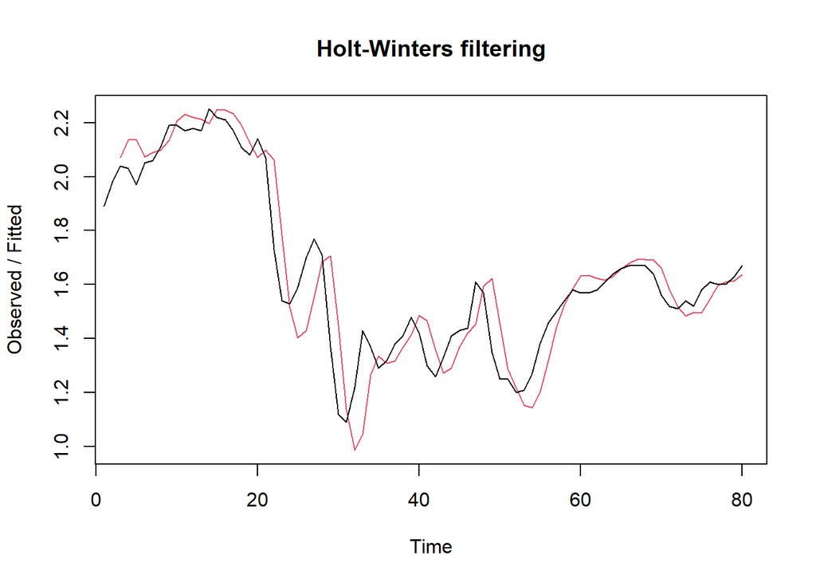

```r
#Lamda=0.6 dan gamma=0.3
des_2<- HoltWinters(train_ma_ts, gamma = FALSE, beta = 0.3, alpha = 0.6)
plot(des_2)
```

```r
#ramalan
ramalandes2<- forecast(des_2, h=10)
ramalandes2
```

```
##    Point Forecast    Lo 80    Hi 80     Lo 95    Hi 95
## 81       1.675686 1.517428 1.833945 1.4336507 1.917722
## 82       1.694681 1.493973 1.895389 1.3877251 2.001637
## 83       1.713676 1.461950 1.965402 1.3286948 2.098657
## 84       1.732671 1.422969 2.042373 1.2590226 2.206319
## 85       1.751666 1.378095 2.125237 1.1803386 2.322993
## 86       1.770661 1.328046 2.213276 1.0937393 2.447582
## 87       1.789656 1.273325 2.305986 0.9999959 2.579315
## 88       1.808650 1.214306 2.402995 0.8996784 2.717622
## 89       1.827645 1.151275 2.504015 0.7932267 2.862064
## 90       1.846640 1.084464 2.608816 0.6809928 3.012287
```

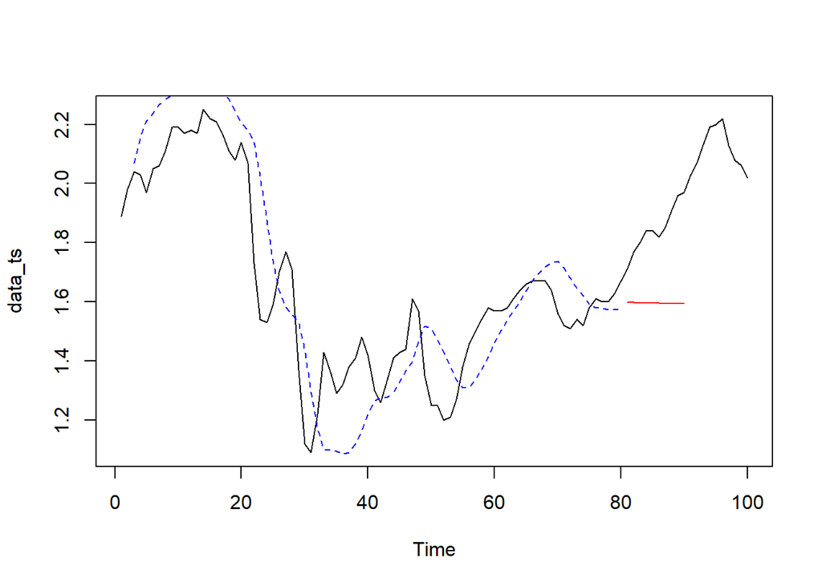

```r
plot(data_ts)
lines(des_1$fitted[,1], lty=2, col="blue")
lines(ramalandes1$mean, col="red")
```

```r
#Lamda dan gamma optimum
des_opt<- HoltWinters(train_ma_ts, gamma = FALSE)
des_opt
```

```
## Holt-Winters exponential smoothing with trend and without seasonal component.
##
## Call:
## HoltWinters(x = train_ma_ts, gamma = FALSE)
##
## Smoothing parameters:
##  alpha: 1
##  beta : 1
##  gamma: FALSE
##
## Coefficients:
##   [,1]
## a 1.67
## b 0.04
```

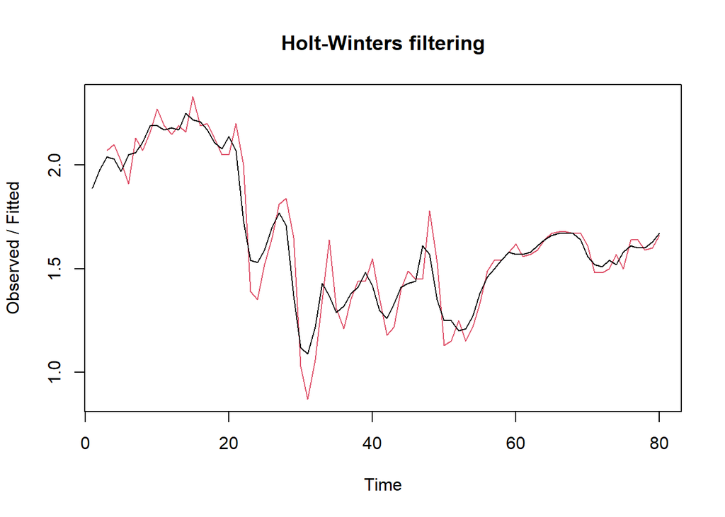

```r
plot(des_opt)
```

```r
#ramalan
ramalandesopt<- forecast(des_opt, h=10)
ramalandesopt
```

```
##    Point Forecast       Lo 80    Hi 80      Lo 95    Hi 95
## 81           1.71  1.58721089 1.832789  1.5222103 1.897790
## 82           1.75  1.47543519 2.024565  1.3300894 2.169911
## 83           1.79  1.33056520 2.249435  1.0873551 2.492645
## 84           1.83  1.15745632 2.502544  0.8014332 2.858567
## 85           1.87  0.95937155 2.780628  0.4773140 3.262686
## 86           1.91  0.73866650 3.081333  0.1186000 3.701400
## 87           1.95  0.49713960 3.402860 -0.2719582 4.171958
## 88           1.99  0.23622065 3.743779 -0.6921741 4.672174
## 89           2.03 -0.04291884 4.102919 -1.1402558 5.200256
## 90           2.07 -0.33929641 4.479296 -1.6147009 5.754701
```

```r
#Akurasi Data Training
ssedes_train1<-des_1$SSE
msedes_train1<-ssedes_train1/length(train_ma_ts)
sisaandes1<-ramalandes1$residuals
head(sisaandes1)
```

```
## Time Series:
## Start = 1
## End = 6
## Frequency = 1
## [1]         NA         NA -0.0300000 -0.1228000 -0.2421280 -0.1879053
```

```r
mapedes_train1 <- sum(abs(sisaandes1[3:length(train_ma_ts)]/train_ma_ts[3:length(train_ma_ts)])
                      *100)/length(train_ma_ts)

akurasides.1 <- matrix(c(ssedes_train1,msedes_train1,mapedes_train1))
rownames(akurasides.1)<- c("SSE", "MSE", "MAPE")
colnames(akurasides.1) <- c("Akurasi lamda=0.2 dan gamma=0.2")
akurasides.1
```

```
##      Akurasi lamda=0.2 dan gamma=0.2
## SSE                       2.38697023
## MSE                       0.02983713
## MAPE                      9.14675710
```

```r
ssedes_train2<-des_2$SSE
msedes_train2<-ssedes_train2/length(train_ma_ts)
sisaandes2<-ramalandes2$residuals
head(sisaandes2)
```

```
## Time Series:
## Start = 1
## End = 6
## Frequency = 1
## [1]          NA          NA -0.03000000 -0.10660000 -0.16805200 -0.02238344
```

```r
mapedes_train2 <- sum(abs(sisaandes2[3:length(train_ma_ts)]/train_ma_ts[3:length(train_ma_ts)])
                      *100)/length(train_ma_ts)

akurasides.2 <- matrix(c(ssedes_train2,msedes_train2,mapedes_train2))
rownames(akurasides.2)<- c("SSE", "MSE", "MAPE")
colnames(akurasides.2) <- c("Akurasi lamda=0.6 dan gamma=0.3")
akurasides.2
```

```
##      Akurasi lamda=0.6 dan gamma=0.3
## SSE                       1.17622514
## MSE                       0.01470281
## MAPE                      5.48836862
```

```r
train_ma.ts <- ts(train_ma_ts, frequency = 6)
test_ma.ts  <- ts(test_ma_ts, frequency = 6, start = end(train_ma_ts) + c(0,1))

# Forecast test
pred_des1 <- forecast(des_1, h=length(test_ma.ts))$mean

# Residual test
resid_des1 <- as.numeric(test_ma.ts) - as.numeric(pred_des1)

# Akurasi
sse_des1_test <- sum(resid_des1^2)
mse_des1_test <- mean(resid_des1^2)
mape_des1_test <- mean(abs(resid_des1 / as.numeric(test_ma.ts))) * 100

# Buat matrix akurasi
akurasi_des1_test <- matrix(c(sse_des1_test, mse_des1_test, mape_des1_test),
                            nrow=3, ncol=1)
row.names(akurasi_des1_test) <- c("SSE", "MSE", "MAPE")
colnames(akurasi_des1_test) <- c("Akurasi DES1 (lamda=0.2, gamma=0.2)")
akurasi_des1_test
```

```
##      Akurasi DES1 (lamda=0.2, gamma=0.2)
## SSE                            3.4638950
## MSE                            0.1731948
## MAPE                          19.0356956
```

```r
pred_des2 <- forecast(des_2, h=length(test_ma.ts))$mean
resid_des2 <- as.numeric(test_ma.ts) - as.numeric(pred_des2)

sse_des2_test <- sum(resid_des2^2)
mse_des2_test <- mean(resid_des2^2)
mape_des2_test <- mean(abs(resid_des2 / as.numeric(test_ma.ts))) * 100

akurasi_des2_test <- matrix(c(sse_des2_test, mse_des2_test, mape_des2_test),
                            nrow=3, ncol=1)
row.names(akurasi_des2_test) <- c("SSE", "MSE", "MAPE")
colnames(akurasi_des2_test) <- c("Akurasi DES2 (lamda=0.6, gamma=0.3)")
akurasi_des2_test
```

```
##      Akurasi DES2 (lamda=0.6, gamma=0.3)
## SSE                           0.43218864
## MSE                           0.02160943
## MAPE                          6.15787628
```